# 프로야구 스피드업을 위한 방안

2018-11-26

## 0. 목차

1. 스피드업?
2. 기존의 스피드업 방안
3. 새로운 스피드업 방안 제시
4. 결론

## 스피드업?

## 1. 스피드업?

## 1. 스피드업?

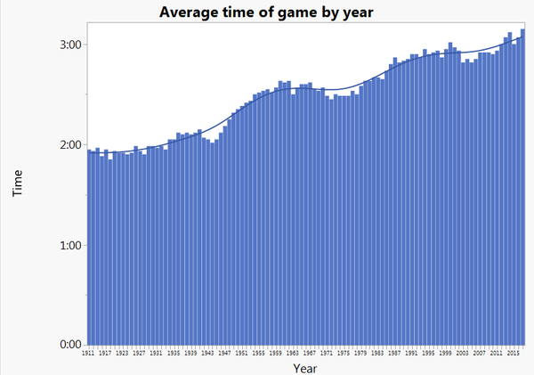

[그림 1: 연도별 MLB 평균 경기 시간]

## 1. 스피드업?

'경기 시간 단축을 위한 프로야구의 방안'

## 1. 스피드업?

'경기 시간 단축을 위한 프로야구의 방안'

- 경기 시간은 왜 늘어났을까?

## 1. 스피드업?

'경기 시간 단축을 위한 프로야구의 방안'

- 경기 시간은 왜 늘어났을까?
  - 운동 능력의 기술적 향상
  - 투수의 분업화
  - 수비 시프트
  - 불필요한 준비 동작
  - 새로운 제도의 도입(비디오 판독 등)

## 1. 스피드업?

2018년 MLB 평균 경기 시간

2018년 KBO 평균 경기 시간

## 1. 스피드업?

2018년 MLB 평균 경기 시간 3시간 4분

2018년 KBO 평균 경기 시간 3시간 21분

## 1. 스피드업?

2018년 MLB 평균 경기 시간 3시간 4분

2018년 KBO 평균 경기 시간 3시간 21분

**무려 17분 차이!!**

## 1. 스피드업?

스피드업에 더 신경을 쓰는 MLB

## 1. 스피드업?

스피드업에 더 신경을 쓰는 MLB

[figure not shown]

[그림 2: MLB 커미셔너, 롭 만프레드]

## 1. 스피드업?

스피드업, 왜?

## 1. 스피드업?

스피드업, 왜?

1. 타 종목에 비해 너무나 긴 경기 시간
   - NFL 3시간 4분
   - NBA 2시간 15분
   - NHL 2시간 20분

## 1. 스피드업?

스피드업, 왜?

1. 타 종목에 비해 너무나 긴 경기 시간
   - NFL 3시간 4분
   - NBA 2시간 15분
   - NHL 2시간 20분

**NFL은 야구와 달리 쉬는 시간이 짧고 박진감 넘치는 경기 진행**

## 1. 스피드업?

스피드업, 왜?

1. 타 종목에 비해 너무나 긴 경기 시간
   - NFL 3시간 4분
   - NBA 2시간 15분
   - NHL 2시간 20분

**NFL은 야구와 달리 쉬는 시간이 짧고 박진감 넘치는 경기 진행**

- 야구라는 스포츠의 특성상 동적인 시간 자체도 길지 않음
- 지루한 어른들의 경기라는 인식이 생김

## 1. 스피드업?

스피드업, 왜?

## 1. 스피드업?

스피드업, 왜?

２. 인기의 감소, NBA에 역전 허용

[figure not shown]

[그림 3: 10년만에 다시 MLB를 넘은 NBA]

## 1. 스피드업?

스피드업, 왜?

３. 젊은 층 팬들의 감소

## 1. 스피드업?

스피드업, 왜?

３. 젊은 층 팬들의 감소

```
- MLB 평균 시청 연령 53세, NFL(47세), NBA(37세)
- 속도감을 추구하는 젊은 층
- 농구, 축구 등으로 유출
```

## 1. 스피드업?

궁극적인 이유

## 1. 스피드업?

궁극적인 이유

현재 야구계에는 스타 선수의 부재 같은 문제도 있으나,

앞으로의 발전에 가장 큰 저해요인이 될 수 있는 것은 '경기 시간'

MLB뿐만아니라 KBO도 천만 관객의 목표를 위해 꼭 선행되어야 할 부분

## 기존의 스피드업 방안

## 2. 기존의 스피드업 방안

## 2. 기존의 스피드업 방안

MLB의 기존 스피드업 방안 - Pace of Play

## 2. 기존의 스피드업 방안

MLB의 기존 스피드업 방안 (2015년)

1. 공수교대 시간 제한 (전국 방송 2분45초, 지역 2분 25초)
2. 40초 선수 테마송
3. 30초 웜업 투구 종료
4. 25초 선수 테마송 종료
5. 20초 ~ 5초 타자 배터박스 입장
6. 20초 ~ 0초 투구 동작
7. 타자 한 발 배터박스에 걸치기
8. 비디오 판독 요청 30초 안에, 덕아웃 안에서

## 2. 기존의 스피드업 방안

MLB의 기존 스피드업 방안 (2016년)

1. 감독, 코치의 마운드 방문 시간 30초로 제한
2. 공수교대 시간 20초 단축

MLB의 기존 스피드업 방안 (2017년)

1. 자동 고의4구
2. 시프트 위치나 야수에게 도움이 되는 필드 마킹 금지
3. 비디오 판독 2분 이내

## 2. 기존의 스피드업 방안

MLB의 기존 스피드업 방안 (2018년)

1. 마운드 방문 횟수 제한
2. 연습투구 시간 제한
3. 비디오 판독실 - 덕아웃 간 전화기 설치

## 2. 기존의 스피드업 방안

KBO의 기존 스피드업 방안

1. 감독, 코치, 포수 마운드 방문 횟수 제한
2. 1, 3루 코치의 스톱워치 사용 금지
3. 클리닝 타임 4분 이내
4. 자동 고의4구
5. 타자 한 발은 꼭 타석 안에
6. 타석에 들어서는 타자는 2개의 배트를 여분으로 미리 준비

아래 홈페이지에 자세하게 소개 https://www.koreabaseball.com/History/Etc/GameSpeedUp.aspx

## 새로운 스피드업 방안 제시

## 3. 새로운 스피드업 방안 제시

## 3. 새로운 스피드업 방안 제시

적극적인 시간 단축이 필요하나, 몇가지 지켜져야 할 부분이 있음

## 3. 새로운 스피드업 방안 제시

적극적인 시간 단축이 필요하나, 몇가지 지켜져야 할 부분이 있음

1. 야구는 기록의 스포츠이기 때문에, 경기 내용적 변화 최소화
2. 선수 노조가 납득할 수 있을 만큼의 변화

## 3. 새로운 스피드업 방안 제시

현실적인 방안 (투고타저)

## 3. 새로운 스피드업 방안 제시

현실적인 방안 (투고타저)

투수의 능력이 상대적으로 떨어질 때 경기 시간이 오래걸림

결과적으로 27개 아웃카운트를 올려야 끝나는 게임이기 때문

- 경기 투구수가 많을 때
- 타자의 타석수가 많을 때
- 볼이 많을 때
- 투수 교체가 잦을 때

## 3. 새로운 스피드업 방안 제시

현실적인 방안 (투고타저)

1. 스트라이크 존 확대
2. 바람직한 투수 육성 문화
3. 경기 시간 사이를 더욱 축소 (투수에 유리하도록)

## 3. 새로운 스피드업 방안 제시

그러나 정말 방법이 없다면?

## 3. 새로운 스피드업 방안 제시

그러나 정말 방법이 없다면?

1. 경기 이닝 축소
2. 스트라이크 / 볼 규정 변화
3. 무승부 제도 도입
4. 콜드게임 규정 도입

## 3. 새로운 스피드업 방안 제시

그러나 정말 방법이 없다면?

1. 경기 이닝 축소
2. 스트라이크 / 볼 규정 변화
3. 무승부 제도 도입
4. 콜드게임 규정 도입

**적극적인 방안의 도입 필요!**

## 결론

## 4. 결론

기존의 스피드업 방안들이 미진한 효과에 그치고 있으나, 그렇다고 적극적인 방안들을 무분별하게 시도하는건 오히려 야구 산업을 내부적으로 와해시킬 수 있다고 생각함. 우선 앞서 소개한 것과 같은 현실적인 방안으로 차근차근 고쳐나가되, 필요하다면 모두와 협의를 통해 큰 부분을 해결해야 할 듯 KBO의 경우 MLB의 규정 변화를 대부분 따르므로 자체적인 적극적 변화는 힘들다고 봄